# Univariate GWAS with wgAim

Author

Julian Taylor & Ari Verbyla

Published

August 5, 2026

## 1 Overview

This vignette demonstrates the complete univariate **wgAim** GWAS pipeline for a diversity panel evaluated in a single environment. The pipeline has three stages:

1. **Pre-analysis** — inspect a raw 0/1/2 marker genotype matrix with `checkPanel()`, apply quality filters with `filterPanel()`, and assemble the analysis-ready `wgPanel` object with `primePanel()` (including KNN imputation of residual missingness).
2. **Analysis** — fit a whole-genome composite marker model and iteratively detect associated markers with `gwasAim()`.
3. **Post-analysis** — interrogate, summarise, and visualise the detected associations using the `print`, `summary`, and `plot` methods, and refine peak positions with `fineMap()`.

Throughout the vignette we use the simulated `genoGWASraw`, `mapGWASsim` and `phenoGWASsim` datasets bundled with the package. `genoGWASraw` and `mapGWASsim` represent a simulated diversity panel of 200 lines genotyped at approximately 1700 SNP markers across 10 chromosomes (about 170 markers per chromosome, average spacing ~0.9 cM). The panel is generated with `AlphaSimR` with 50 founder haplotypes via a coalescent (`runMacs2`), one generation of random mating to produce 200 F1 diverse lines, then a SNP chip actively selected from segregating sites with minor allele frequency (MAF) > 0.15. All shipped markers have F1 MAF > 0.15 (median ~0.32), so the panel is dominated by informative common variants. The resulting kinship matrix $\boldsymbol{K}$ has genuine full-rank structure (off-diagonal SD ~0.085) and captures the half-sib / full-sib relatedness naturally. The raw marker matrix deliberately contains a range of realistic data-quality issues (missingness, monomorphic markers, duplicate lines, duplicate markers and markers absent from the map) so the full pre-analysis pipeline can be exercised. Five QTL were planted at known positions to give ground truth for detection.

See `?phenoGWASsim` or the **Overview** section of the Multivariate GWAS Mapping vignette for a more detailed specification of the phenotype data. In this single-environment vignette we have restricted the analysis to `Env1` only.

**Requires:** ASReml-R V4. The vignette is pre-rendered so no licence is needed to read it. Run the code chunks only if you have ASReml-R installed.

## 2 Mathematical Framework

The mathematical framework underpinning `gwasAim()` is essentially identical to that of `qtlAim()`. Please see the **Mathematical Framework** section of the Univariate QTL Mapping vignette for the full algorithmic pipeline.

### 2.1 What’s different in GWAS

Only three things distinguish the GWAS pipeline from biparental interval mapping at the modelling level:

1. **Marker matrix source.** `qtlAim()` operates on virtual mid-interval scores constructed by `primeCross(type = "interval")` ($\lambda$-weighted dosages in $[-1, +1]$). `gwasAim()` operates on the *actual* panel markers assembled by `primePanel()`, coded $\pm 1$ for the two alleles after the $x \mapsto x - 1$ shift from raw $0/1/2$ counts (heterozygotes at $0$). No interval mid-points are constructed; each panel marker is used directly.
2. **Population structure.** Diversity panels typically carry both short-range LD and long-range stratification from subpopulations. Both are absorbed by the composite additive term via $\boldsymbol{K}$ in the vm path, so no additional principal- component covariates or kinship correction are required in the base model.
3. **The vm path dominates.** Panels almost always satisfy $p \gg n$ (many more markers than lines), so `gwasAim()` selects the vm formulation automatically. The mbf ridge formulation is available via `force = TRUE` when $n \geq p$ or for diagnostic comparison.

The **exclusion window** (argument `exclusion.window`, default 20) is expressed in the units of the map’s `pos` column and these are cM for a genetic map, or Mb / kb / bp for a physical map.

## 3 Data Preparation

The pre-analysis pipeline has three functions applied in sequence:

1. `checkPanel()` — pure diagnostic; reports data-quality issues but does not modify the data.
2. `filterPanel()` — applies quality thresholds in a principled order.
3. `primePanel()` — converts the clean matrix into a `wgPanel` object and optionally imputes any remaining missing values.

```r
data(genoGWASraw,  package = "wgAim")
data(mapGWASsim,   package = "wgAim")
data(phenoGWASsim, package = "wgAim")

cat(sprintf("Raw geno    : %d lines x %d marker columns\n",
            nrow(genoGWASraw), ncol(genoGWASraw) - 1L))
```

```
Raw geno    : 200 lines x 1691 marker columns
```

```r
cat(sprintf("Map         : %d markers x %d columns\n",
            nrow(mapGWASsim), ncol(mapGWASsim)))
```

```
Map         : 1691 markers x 3 columns
```

```r
cat(sprintf("Phenotype   : %d rows across %d sites\n",
            nrow(phenoGWASsim), nlevels(phenoGWASsim$Site)))
```

```
Phenotype   : 2400 rows across 6 sites
```

A quick look at the raw genotype matrix — a `data.frame` with an `id` column followed by one column per marker in 0/1/2 allele-count coding:

```r
genoGWASraw[1:6, 1:8]
```

```
             id SNP_C01_0001 SNP_C01_0002 SNP_C01_0003 SNP_C01_0004
Line001 Line001            0            1            2            1
Line002 Line002            0            1            2            1
Line003 Line003            0            0            1            0
Line004 Line004            0            0            2            0
Line005 Line005            0            1            1            1
Line006 Line006            0            0            2            1
        SNP_C01_0005 SNP_C01_0006 SNP_C01_0007
Line001            2            2            0
Line002            2            2            0
Line003            2            2            0
Line004            2            2            0
Line005            1            1            1
Line006            1            1            1
```

### 3.1 Step 1 — Diagnostic scan with `checkPanel()`

`checkPanel()` is a pure diagnostic. It computes summary statistics on the raw matrix, cross-references marker names against the map, and reports data-quality issues but does not modify the data. The results guide the choice of thresholds for the subsequent `filterPanel()` step.

```r
chk <- checkPanel(genoGWASraw, mapGWASsim,
                   id       = "id",
                   map.id   = "marker",
                   map.chr  = "chr",
                   map.pos  = "pos",
                   encoding = "012")
print(chk)
```

```
Panel Check Summary
====================================================
  Lines: 200  |  Markers: 1691  |  Chromosomes: 10
  Encoding: 012

Encoding validation:
  OK -- values within expected range.

Map consistency:
  Markers in geno, not in map : 25
  Markers in map,  not in geno: 25

Duplicates:
  Duplicate lines  : 4
  Duplicate markers: 54

Missingness:
  Lines   -- Mean: 5.6%  Max: 39.6%  (6 above 20% threshold)
  Markers -- Mean: 5.6%  Max: 46.5%  (150 above 20% threshold)

MAF distribution:
  Min: 0.000  Median: 0.319  Mean: 0.319  Max: 0.500
  Monomorphic markers (MAF = 0): 15
  Markers removed at standard thresholds:
    MAF < 0.01 :   15 markers ( 0.9%)
    MAF < 0.02 :   15 markers ( 0.9%)
    MAF < 0.05 :   15 markers ( 0.9%)
    MAF < 0.10 :   15 markers ( 0.9%)

Heterozygosity:
  Per line   -- Mean: 0.418  Max: 0.472  (200 above 10% threshold)
  Per marker -- Mean: 0.419  Max: 0.648  (1651 above 10% threshold)

Chromosome coverage:
  Chromosome     Markers  Range (pos)
  ------------   -------  -------------------
  Chr1               167  0.0 – 148.3
  Chr2               166  0.3 – 149.9
  Chr3               162  0.3 – 149.2
  Chr4               167  0.0 – 149.7
  Chr5               168  0.6 – 148.6
  Chr6               167  0.2 – 149.7
  Chr7               167  0.7 – 148.3
  Chr8               168  0.0 – 148.7
  Chr9               169  2.2 – 149.3
  Chr10              165  3.9 – 149.6
```

### 3.2 Step 2 — Apply filters with `filterPanel()`

`filterPanel()` uses the diagnostics to apply data-quality thresholds in a principled order controlled by a `steps` argument. The default `steps` list implements the standard workflow:

1. Map consistency — drop markers absent from the map.
2. Marker missingness (default 20%).
3. Line missingness (default 20%).
4. Duplicate lines.
5. Duplicate markers *(off by default; enable if desired)*.
6. MAF (default 0.05).

The `checkPanel` object can be piped directly into `filterPanel()`; all metadata (id column, map field names, encoding) is carried through automatically.

```r
flt <- filterPanel(chk)   # accepts the checkPanel object directly
print(flt)
```

```
Filter History
====================================================
  Original : 200 lines,  1691 markers

  Step 1 [Map consistency                    ]: removed 25 marker(s)
  Step 2 [Marker missingness > 20%           ]: removed 150 marker(s)
  Step 3 [Line missingness > 20%             ]: removed 6 line(s)
  Step 4 [Duplicate lines                    ]: removed 3 line(s)
  Step 5 [Duplicate markers                  ]: skipped
  Step 6 [MAF < 0.05                         ]: removed 15 marker(s)
  After    : 191 lines,  1501 markers

  Remaining: 191 lines,  1501 markers
```

### 3.3 Step 3 — Build the `wgPanel` with `primePanel()`

`primePanel()` converts the filtered matrix into the internal object class used by `gwasAim()`. It applies the $x \mapsto x-1$ encoding shift so alleles are represented as $\pm 1$ (or dosage in $[-1, 1]$) with heterozygotes at 0, splits the matrix by chromosome, sorts by position within each chromosome and optionally imputes any remaining missing values. The recommended in-package option is chromosome-wise KNN imputation, which uses BLAS-accelerated pairwise distances and pre-sorted neighbour indices to respect the LD structure within each chromosome.

```r
panel <- primePanel(flt, impute = "knn", knn.k = 5)
cat("Class          :", paste(class(panel), collapse = ", "), "\n")
```

```
Class          : wgPanel, wgCross, cross
```

```r
cat("Chromosomes    :", length(panel$geno), "\n")
```

```
Chromosomes    : 10
```

```r
cat("Markers total  :",
    sum(sapply(panel$geno, function(el) ncol(el$imputed.data))), "\n")
```

```
Markers total  : 1501
```

```r
cat("Lines in panel :", nrow(panel$pheno), "\n")
```

```
Lines in panel : 191
```

The `wgPanel` object stores per-chromosome marker matrices in `panel$geno[[ch]]$imputed.data` alongside their cM positions in `panel$geno[[ch]]$map`. A `linkMap()` call gives a visual summary of the prepared panel:

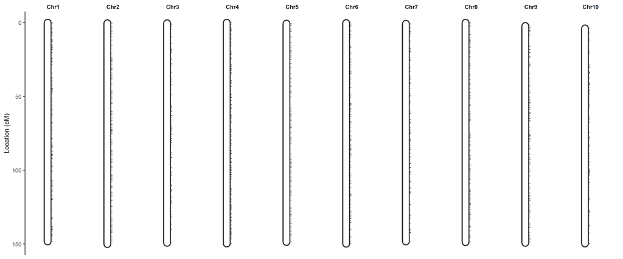

```r
linkMap(panel, nrow = 1, marker.names = "none") +
  theme(plot.title = element_blank())
```

## 4 Base Model — single environment (`Env1`)

For the single-environment GWAS we subset the phenotype to `Env1` and fit a base model that captures the design structure. The trial is a 2-replicate RCBD with row and column plot coordinates. A simple and robust choice is a random-effect model for lines, rows and columns:

```r
env1 <- droplevels(phenoGWASsim[phenoGWASsim$Site == "Env1", ])
env1$Row    <- factor(env1$Row)
env1$Column <- factor(env1$Column)
env1$Rep    <- factor(env1$Rep)

base_env1 <- asreml(
  fixed     = yield ~ Rep,
  random    = ~ id + Row + Column,
  data      = env1,
  na.action = na.method(x = "include"),
  maxit     = 80
)
base_env1 <- update(base_env1)
```

```r
summary(base_env1)$varcomp
```

```
           component   std.error    z.ratio bound %ch
Row     1.509582e-08          NA         NA     B 0.0
Column  2.965897e-04 0.003780844 0.07844535     P 0.6
id      1.158751e-01 0.020573413 5.63227251     P 0.0
units!R 1.491787e-01 0.015202336 9.81287670     P 0.0
```

## 5 Running `gwasAim()`

`gwasAim()` takes the converged base model and the `wgPanel` object. `merge.by` names the shared line-identifier column (present in both `env1` and `panel$pheno`). The default `exclusion.window = 20` acts as a proxy for LD-based exclusion — in this vignette the map is in cM, so 20 means “no other detected marker within 20 cM”:

```r
gwas_env1 <- gwasAim(
  baseModel        = base_env1,
  genObj           = panel,
  merge.by         = "id",
  exclusion.window = 20,
  TypeI            = 0.05,
  trace            = FALSE,
  na.action        = na.method(x = "include"),
  maxit            = 80
)
```

The engine path (vm or mbf) is selected automatically. With ~191 lines and ~1500 markers after filtering, we sit firmly in the vm regime and the genomic relationship matrix $\boldsymbol{K} = \tfrac{1}{p}\boldsymbol{M}\boldsymbol{M}^{\top}$ is used:

```r
cat("Class              :", paste(class(gwas_env1), collapse = ", "), "\n")
```

```
Class              : gwasAim, asreml
```

```r
cat("Markers in panel   :", gwas_env1$QTL$n.markers, "\n")
```

```
Markers in panel   : 1501
```

```r
cat("Significant markers:", length(gwas_env1$QTL$qtl), "\n")
```

```
Significant markers: 4
```

## 6 Results

### 6.1 `print()` — brief narrative

`print()` reports the significance threshold, panel size and one line per detected marker with its chromosome, name and cM position:

```r
print(gwas_env1, genObj = panel)
```

```
GWAS forward selection  TypeI = 0.0500  (1501 markers in panel)

Significant marker on chromosome Chr3: SNP_C03_0128 (110.03 cM)

Significant marker on chromosome Chr2: SNP_C02_0044 (46.00 cM)

Significant marker on chromosome Chr7: SNP_C07_0042 (30.35 cM)

Significant marker on chromosome Chr9: SNP_C09_0068 (60.72 cM)
```

### 6.2 `summary()` — final marker table

`summary()` collates the final model into a table with one row per detected marker: flanking marker name, cM position, estimated additive effect, p-value, percentage of phenotypic variance explained and LOD score:

```r
summ_env1 <- summary(gwas_env1, genObj = panel)
print(summ_env1)
```

```
  Chromosome       Marker dist(cM)    Size  Pvalue Perc.Var   LOD
1       Chr2 SNP_C02_0044    46.00  0.1915   1e-06     18.1  5.35
2       Chr3 SNP_C03_0128   110.03  0.2980  <1e-06     43.7 14.80
3       Chr7 SNP_C07_0042    30.35  0.1583   2e-06     12.3  4.87
4       Chr9 SNP_C09_0068    60.72 -0.1421 3.7e-05      9.9  3.69
```

## 7 Visualisation — `plot()`

Six complementary plot types are available via the `type` argument of `plot.gwasAim()`. The default is `"manhattan"`, the classic GWAS display.

### 7.1 Manhattan plot — `type = "manhattan"` (default)

A classic Manhattan plot: one point per marker, alternating chromosome backgrounds, significant markers highlighted in `sig.col` with labels. One facet per forward-selection iteration shows the outlier statistic before each marker is nominated:

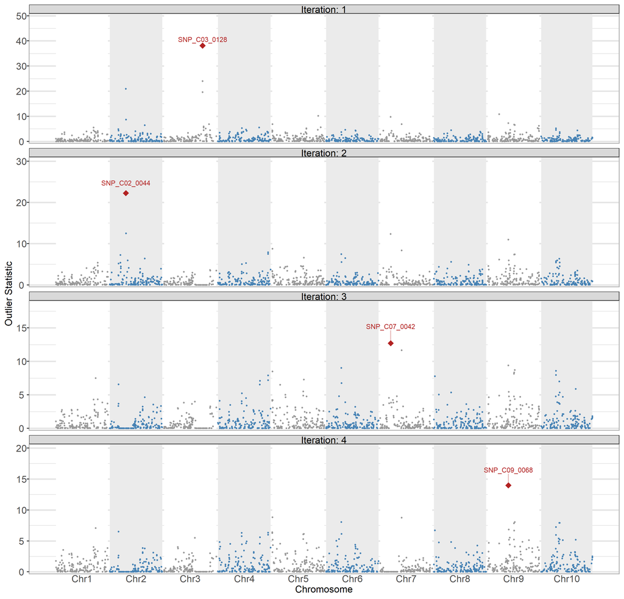

Manhattan plots across all forward-selection iterations. Each panel shows the genome-wide outlier statistic $\tilde{q}_k^2/\tilde{v}_k$; the significant marker for that iteration is highlighted and labelled.

```r
plot(gwas_env1, genObj = panel, type = "manhattan", sig.col = "firebrick")
```

### 7.2 Genome-wide outlier statistics — `type = "outlier"`

The outlier plot displays the same genome-wide statistic as line traces faceted by iteration (an alternative to the Manhattan view). Chromosomal regions that persistently carry signal show up as tall peaks across multiple iterations:

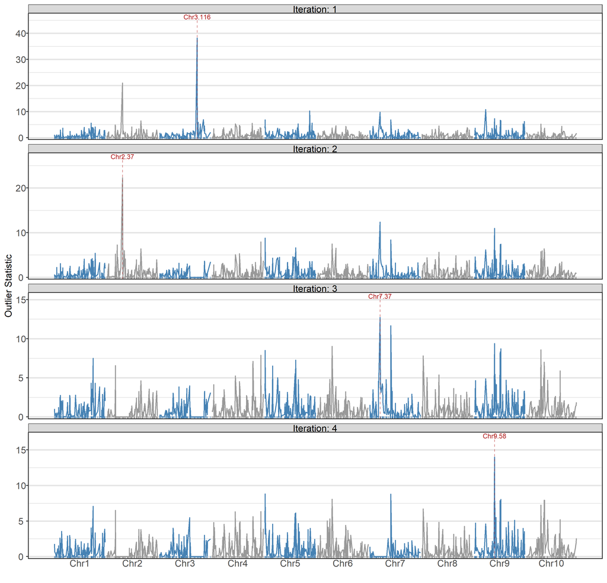

Line-plot view of the genome-wide outlier statistic at each forward-selection iteration. Vertical dashed lines mark the selected marker in each iteration.

```r
plot(gwas_env1, genObj = panel, type = "outlier", sig.col = "firebrick")
```

### 7.3 Scaled genome-wide BLUPs — `type = "blups"`

The BLUPs plot shows the scaled posterior means $\tilde{q}_k / \sqrt{|\tilde{v}_k|}$ at every marker. Markers close to a detected association naturally shrink towards zero as the association absorbs the nearby signal in subsequent iterations:

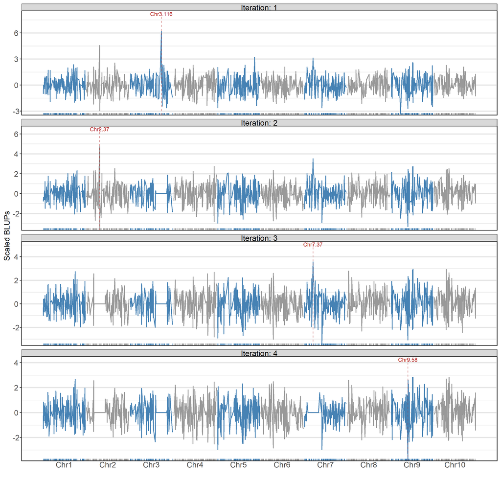

Scaled composite BLUPs across the genome at each iteration.

```r
plot(gwas_env1, genObj = panel, type = "blups", sig.col = "firebrick")
```

### 7.4 Allele effects — `type = "effects"`

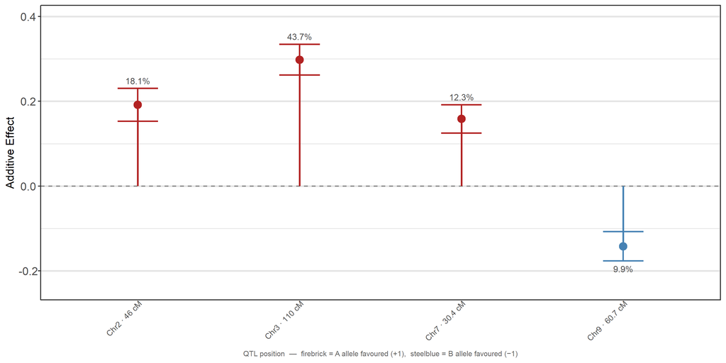

Allele effects and percentage variance explained for each detected marker.

```r
plot(gwas_env1, genObj = panel, type = "effects")
```

### 7.5 Allele contrast — `type = "contrast"`

The contrast plot displays the total genetic value for each line against its dosage class (0, 1, 2) at each detected marker. The total genetic value combines three components: the composite genome-wide BLUP, the residual line-level genetic effect, and the summed fixed marker contributions $\sum_k \hat{\beta}_k x_{ik}$.

This plot requires `data`, the augmented phenotypic data frame that `gwasAim()` writes back to the calling environment as `<response>.data` (here `yield.data`, which contains the original phenotype columns plus `Gomit` and the `X.<chr>.<idx>` dosage columns for each detected marker):

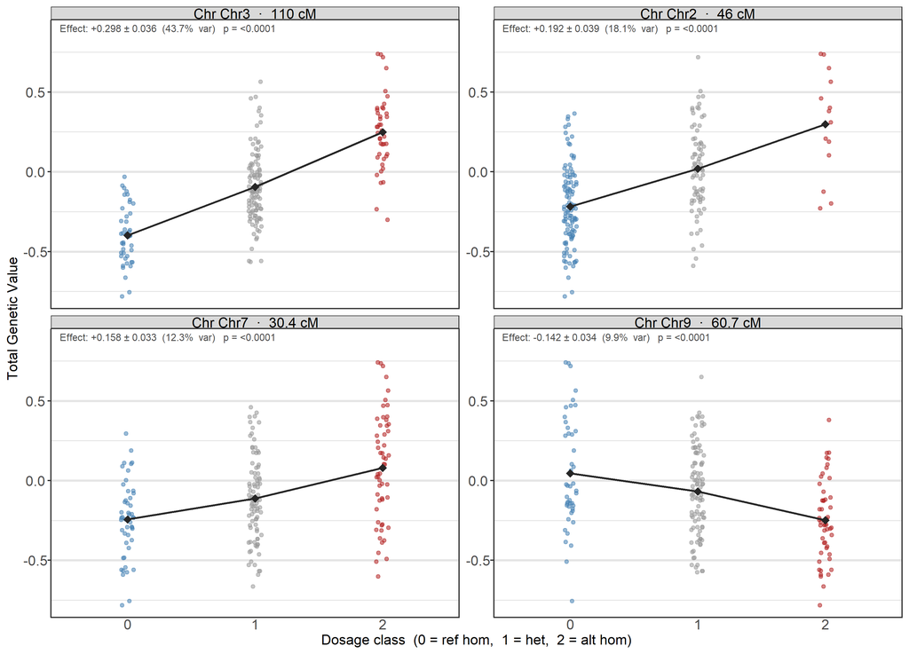

Total genetic value by dosage class (0/1/2) at each detected marker, faceted in two columns. Group means +/- SE are overlaid.

```r
plot(gwas_env1, genObj = panel, type = "contrast",
     data = yield.data, ncol = 2)
```

### 7.6 Iteration heatmap — `type = "heatmap"`

The heatmap gives a compact genome × iteration view, filling each cell with the outlier statistic. This makes it easy to see which chromosomal regions carried persistent signal across iterations:

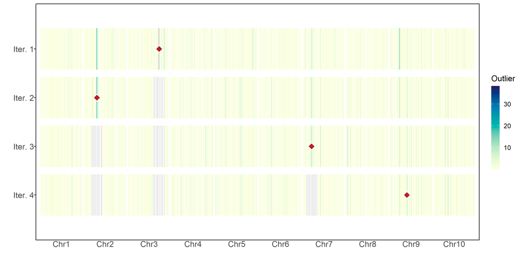

Iteration × genome heatmap of the outlier statistic. Detected markers are annotated with a filled diamond.

```r
plot(gwas_env1, genObj = panel, type = "heatmap", sig.col = "firebrick")
```

### 7.7 Linkage map overlay — `linkMap()`

`linkMap()` overlays the detected markers on the panel map, with marker names annotated on the right and the trait label on the left:

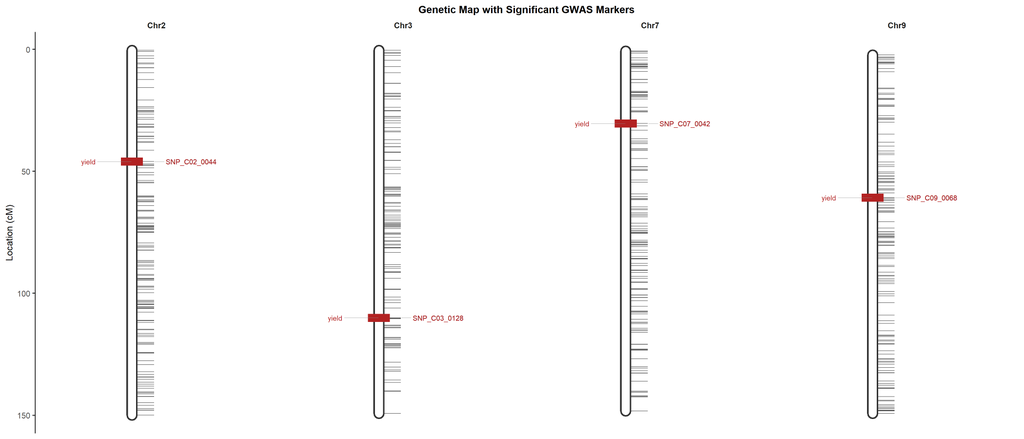

Genetic map with detected GWAS markers overlaid. Marker names are annotated on the right; the trait label on the left.

```r
linkMap(gwas_env1, genObj = panel, marker.names = "markers")
```

## 8 Iteration Diagnostics — `aimTrace()`

`aimTrace()` traces how the LRT statistic and marker effect estimates evolved across the forward-selection iterations. Two diagnostic plots are available.

### 8.1 LRT trace — `plot = "lrt"`

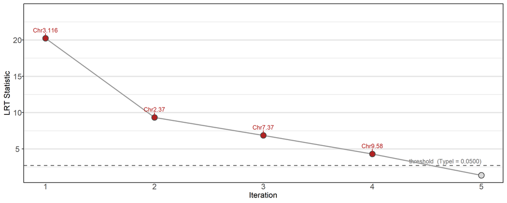

LRT statistic at each iteration. The dashed line is the chi-squared boundary threshold at TypeI = 0.05.

```r
aimTrace(gwas_env1, plot = "lrt", print.out = FALSE)
```

### 8.2 Effect stability — `plot = "stability"`

The stability plot traces each detected marker’s allele effect ± 1 SE across every iteration in which it was present in the model. Effects that remain stable indicate the marker’s contribution is well-identified and not aliased with later-detected markers:

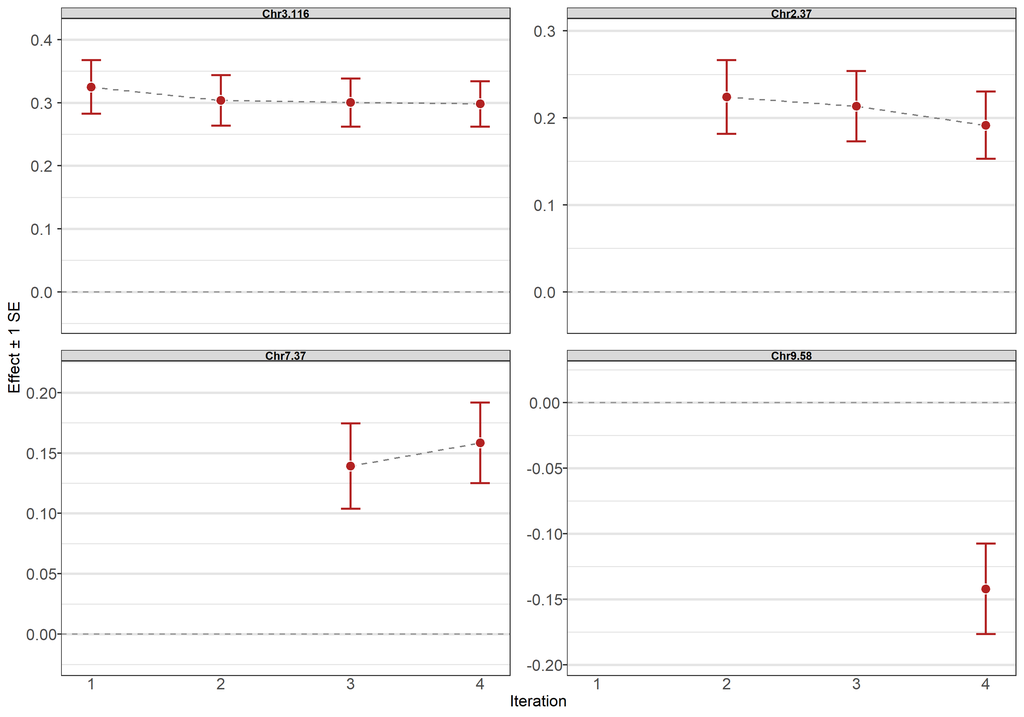

Marker allele effect estimates +/- 1 SE across iterations, laid out 2 x 2.

```r
aimTrace(gwas_env1, plot = "stability", print.out = FALSE, ncol = 2)
```

## 9 Fine Mapping — `fineMap()`

`fineMap()` performs a high-resolution single-marker scan in a window around each detected marker, holding all other detected effects fixed in the model. For `gwasAim` objects this scans the *actual* panel markers within `± window` cM of the peak (no interpolation), reporting per-marker z-ratio p-values and LOD scores.

We fine-map the two markers detected first in forward selection — these are the strongest signals by construction, since `gwasAim()` promotes markers greedily by outlier statistic. A 25 cM window with the default `exclusion.window = 20` gives good resolution around each peak:

```r
top2 <- head(gwas_env1$QTL$qtl, 2L)
fm <- fineMap(gwas_env1, genObj = panel,
              qtl              = top2,
              window           = 25,
              exclusion.window = 20)
```

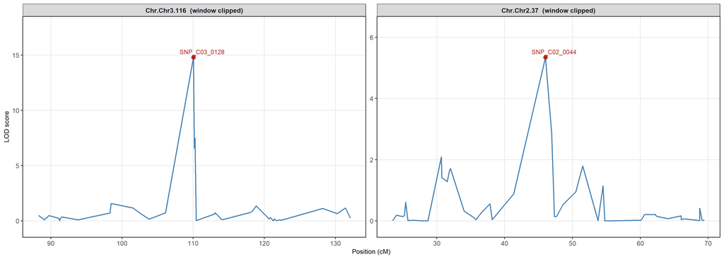

Fine-mapping LOD profiles for the two strongest GWAS peaks.

```r
plot(fm, ncol = 2)
```

## 10 Summary

The complete single-environment GWAS pipeline illustrated in this vignette is:

```r
# 1. Pre-analysis: check -> filter -> prime
chk   <- checkPanel(genoGWASraw, mapGWASsim, id = "id")
flt   <- filterPanel(chk)               # default step list
panel <- primePanel(flt, impute = "knn", knn.k = 5)

# 2. Subset phenotype to the environment of interest
env1  <- droplevels(phenoGWASsim[phenoGWASsim$Site == "Env1", ])
env1$Row    <- factor(env1$Row)
env1$Column <- factor(env1$Column)
env1$Rep    <- factor(env1$Rep)

# 3. Base model (no genomic term)
base_env1 <- asreml(yield ~ Rep, random = ~ id + Row + Column,
                    data = env1, na.action = na.method(x = "include"))

# 4. GWAS forward selection
gwas_env1 <- gwasAim(base_env1, genObj = panel, merge.by = "id",
                     TypeI = 0.05, exclusion.window = 20)

# 5. Results
summary(gwas_env1, genObj = panel)                # final marker table
plot(gwas_env1,    genObj = panel)                # Manhattan (default)
plot(gwas_env1,    genObj = panel, type = "outlier")
plot(gwas_env1,    genObj = panel, type = "blups")
plot(gwas_env1,    genObj = panel, type = "effects")
plot(gwas_env1,    genObj = panel, type = "contrast", data = yield.data)
plot(gwas_env1,    genObj = panel, type = "heatmap")
aimTrace(gwas_env1, plot = "lrt")
aimTrace(gwas_env1, plot = "stability")
linkMap(gwas_env1,  genObj = panel)

# 6. Fine mapping (top two markers in detection order)
top2 <- head(gwas_env1$QTL$qtl, 2L)
fm <- fineMap(gwas_env1, genObj = panel, qtl = top2, window = 25)
plot(fm, ncol = 2)
```

## 11 References

Verbyla, A.P., Cullis, B.R. & Thompson, R. (2007). The analysis of QTL by simultaneous use of the full linkage map. *Theoretical and Applied Genetics*, **116**, 95–111. https://doi.org/10.1007/s00122-007-0676-4

Verbyla, A.P., Taylor, J.D. & Verbyla, K.L. (2012). RWGAIM: An efficient high-dimensional random whole genome average (QTL) interval mapping approach. *Genetics Research*, **94**, 291–306. https://doi.org/10.1017/S0016672312000493

Taylor, J. & Verbyla, A.P. (2011). R Package wgaim: QTL Analysis in Bi-Parental Populations Using Linear Mixed Models. *Journal of Statistical Software*, **40**(7), 1–18. https://doi.org/10.18637/jss.v040.i07

VanRaden, P.M. (2008). Efficient methods to compute genomic predictions. *Journal of Dairy Science*, **91**(11), 4414–4423. https://doi.org/10.3168/jds.2007-0980